# Advanced statistics for physics analysis - Exercise 2

Matteo Bortoletto, matr. 1242935

4/22/2020

## Exercise 0

Practice with the discrete probability distributions in R: make plots of the standard pdfs and cdfs, playing with the function parameters.

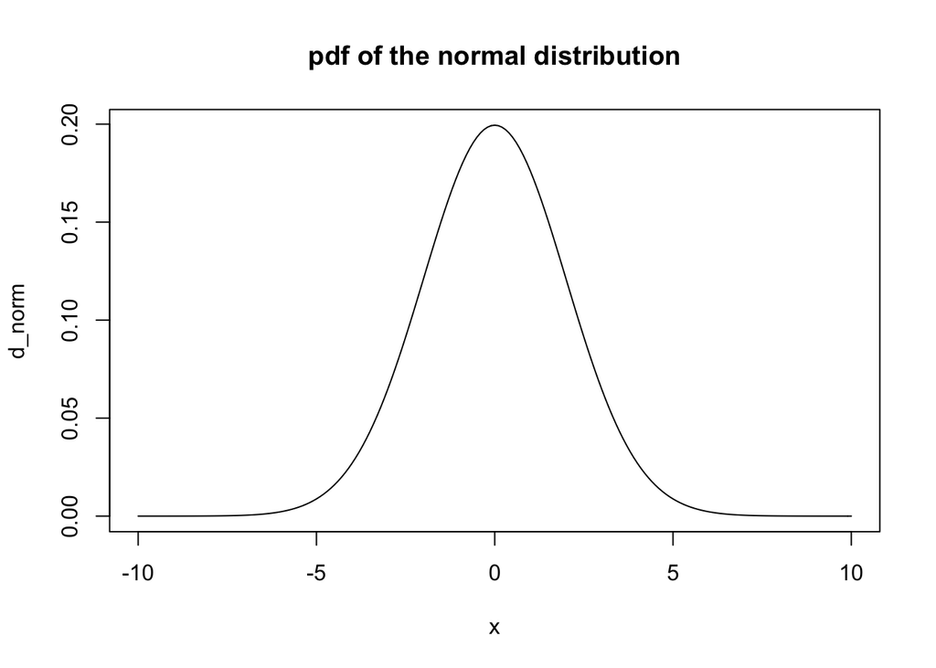

```r
xn <- seq(-10,10,0.1)
d_norm <- dnorm(xn,mean=0,sd=2)
p_norm <- pnorm(xn,0,2)
plot(xn, d_norm,
     type = "l",
     main = "pdf of the normal distribution",
     xlab = "x")
```

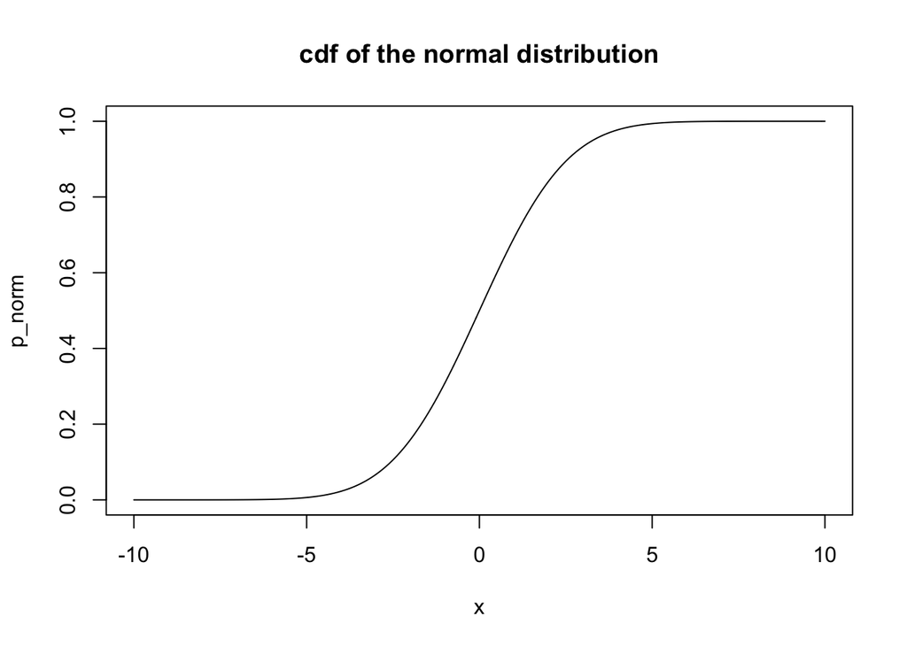

```r
plot(xn, p_norm,
     type = "l",
     main = "cdf of the normal distribution",
     xlab = "x")
```

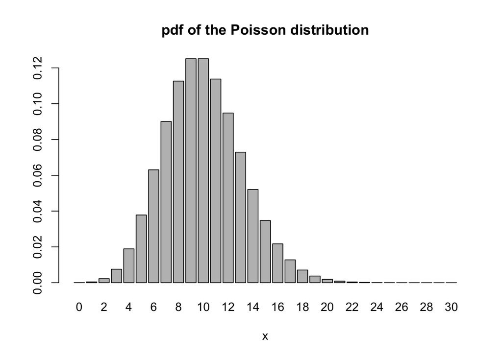

```r
xp <- seq(0,30,1)
d_pois <- dpois(xp,lambda = 10)
p_pois <- ppois(xp,lambda = 10)
barplot(d_pois,
        main = "pdf of the Poisson distribution",
        xlab = "x",
        names = xp)
```

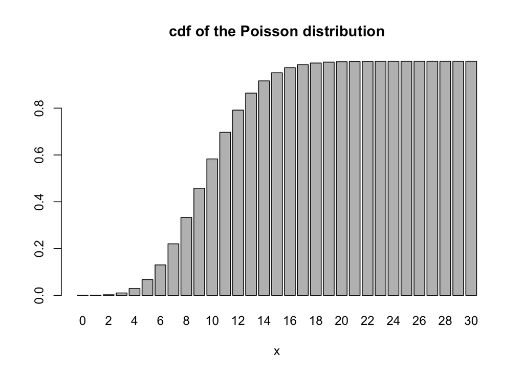

```r
barplot(p_pois,
        main = "cdf of the Poisson distribution",
        xlab = "x",
        names = xp)
```

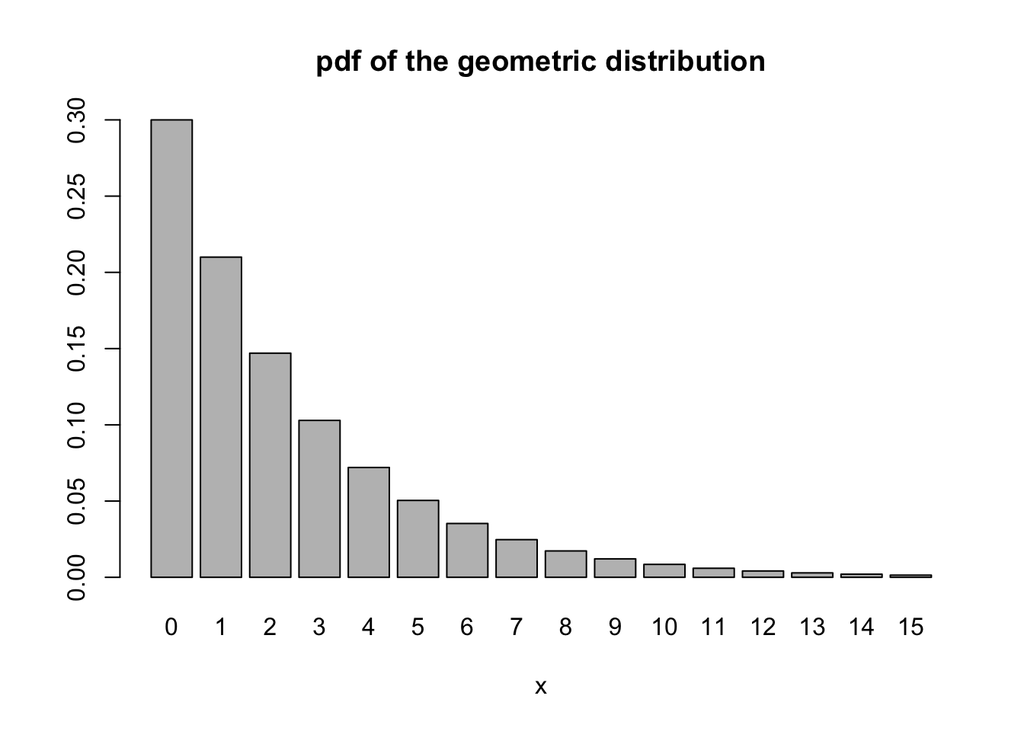

```r
xg <- seq(0,15,1)
d_geom <- dgeom(xg,prob=0.3)
p_geom <- pgeom(xg,prob=0.3)
barplot(d_geom,
        main = "pdf of the geometric distribution",
        xlab = "x",
        names = xg)
```

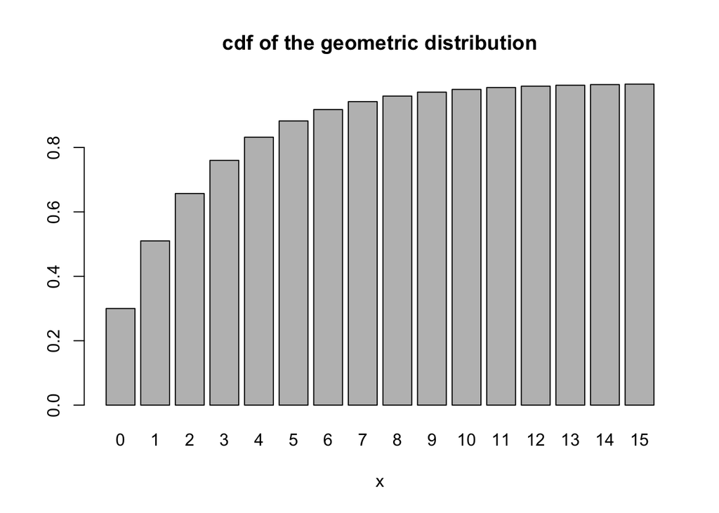

```r
barplot(p_geom,
        main = "cdf of the geometric distribution",
        xlab = "x",
        names = xg)
```

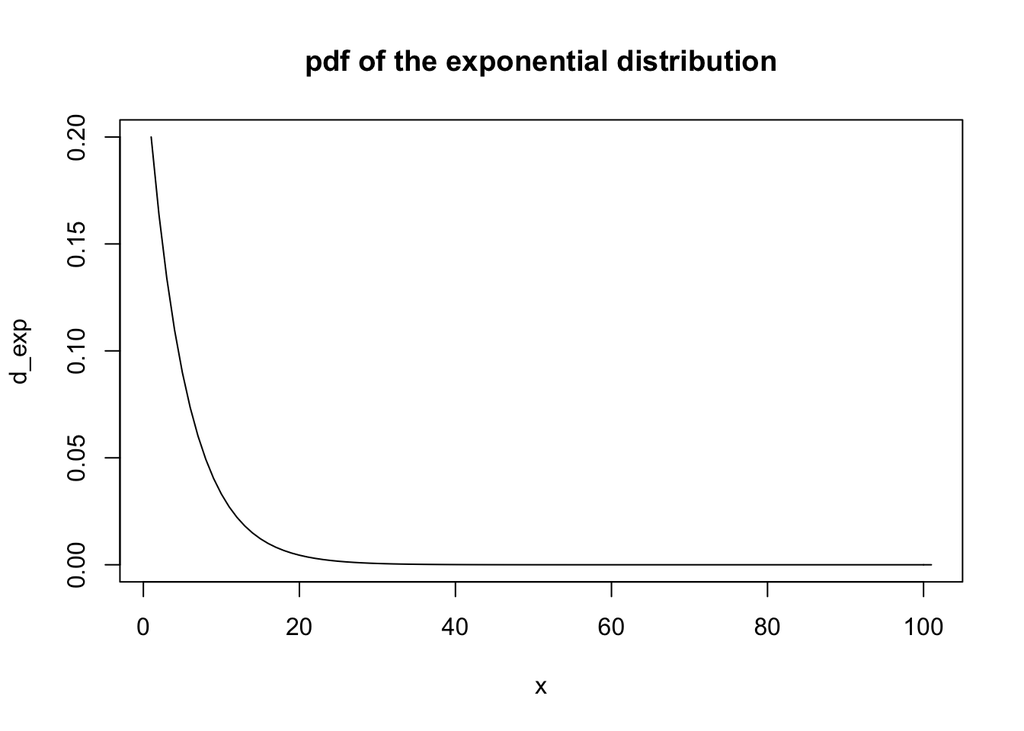

```r
xe <- seq(0,100,1)
d_exp <- dexp(xe,rate=0.2)
p_exp <- pexp(xe,rate=0.2)
plot(d_exp,
     type = "l",
     main = "pdf of the exponential distribution",
     xlab = "x")
```

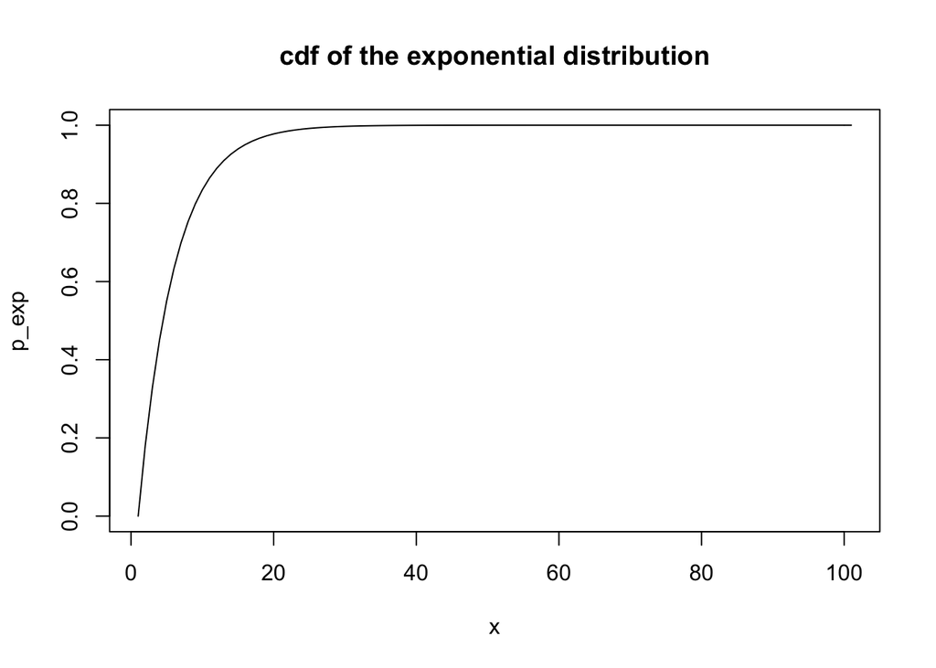

```r
plot(p_exp,
     type = "l",
     main = "cdf of the exponential distribution",
     xlab = "x")
```

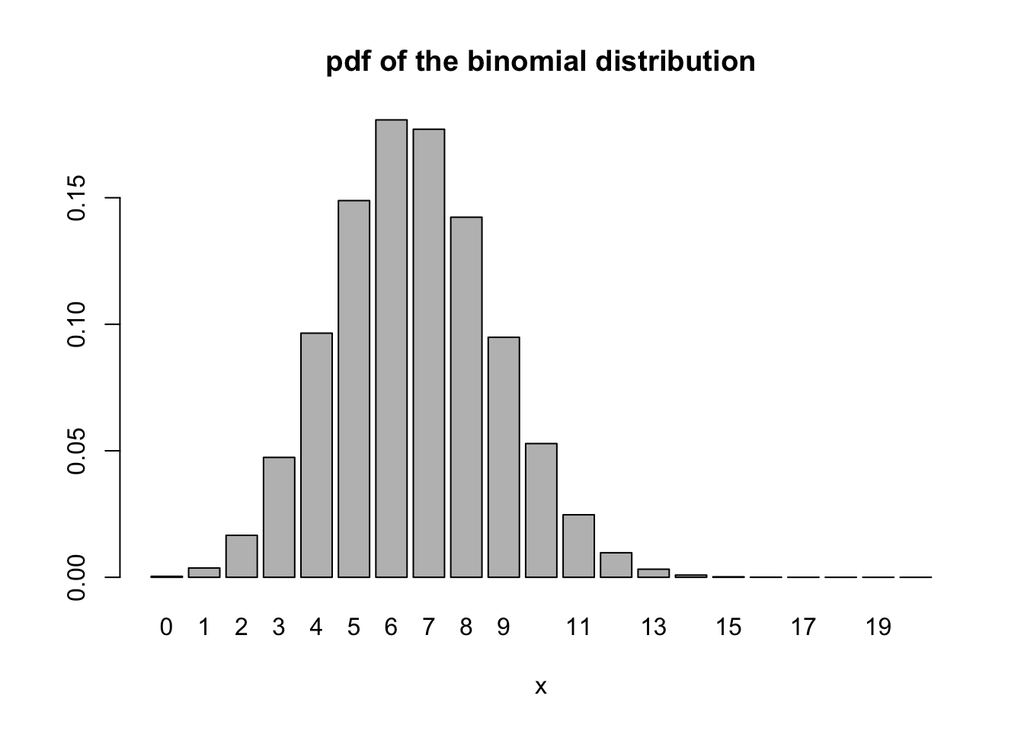

```r
xb <- seq(0,20,1)
d_bin <- dbinom(xb,size=22,prob=0.3)
p_bin <- pbinom(xb,size=22,prob=0.3)
barplot(d_bin,
        main = "pdf of the binomial distribution",
        xlab = "x",
        names = xb)
```

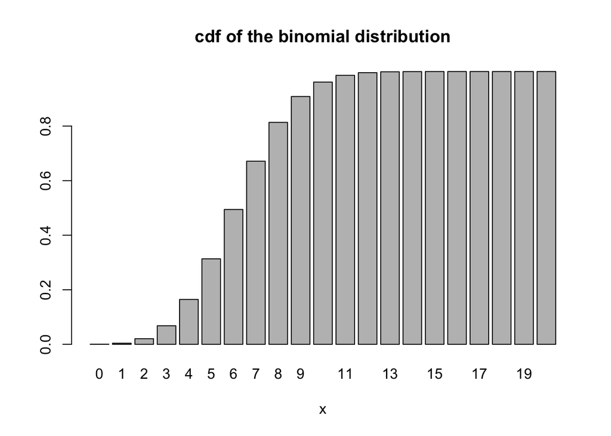

```r
barplot(p_bin,
        main = "cdf of the binomial distribution",
        xlab= "x",
        names = xb)
```

## Exercise 1

A set of measurements have been performed on the concentration of a contaminant in tap water. The table reports a set of values ($x$), with the corresponding probabilities given by the two methods ($p_1$ and $p_2$). Evaluate the expected values, $E[X]$, and the variance, $Var(X)$, for both methods.

```r
x <- c(15.58, 15.9, 16, 16.1, 16.2)
p1 <- c(0.15, 0.21, 0.35, 0.15, 0.14)
p2 <- c(0.14, 0.05, 0.64, 0.08, 0.09)
df <- data.frame(x, p1, p2)
m1 <- sum(df[,1]*df[2])
m2 <- sum(df[,1]*df[3])
v1 <- sum(df[,1]**2*df[,2]) - m1**2
v2 <- sum(df[,1]**2*df[,3]) - m2**2
cat(paste("Method 1. E[X] =", m1, "Var(X) =", v1, "\n"))
```

```
## Method 1. E[X] = 15.959 Var(X) = 0.0339790000000164
```

```r
cat(paste("Method 2. E[X] =", m2, "Var(X) =", v2))
```

```
## Method 2. E[X] = 15.9622 Var(X) = 0.0281671599999811
```

## Exercise 2

The waiting time, in minutes, at the doctor’s is about 30 minutes, and the distribution follows an exponential pdf with rate 1/30.

1. simulate the waiting time for 50 people at the doctor’s office and plot the relative histogram
2. what is the probability that a person will wait for less than 10 minutes?
3. evaluate the average waiting time from the simulated data and compare it with the expected value (calculated from theory and by manipulating the probability distributions using R)
4. what is the probability for waiting more than one hour before being received?

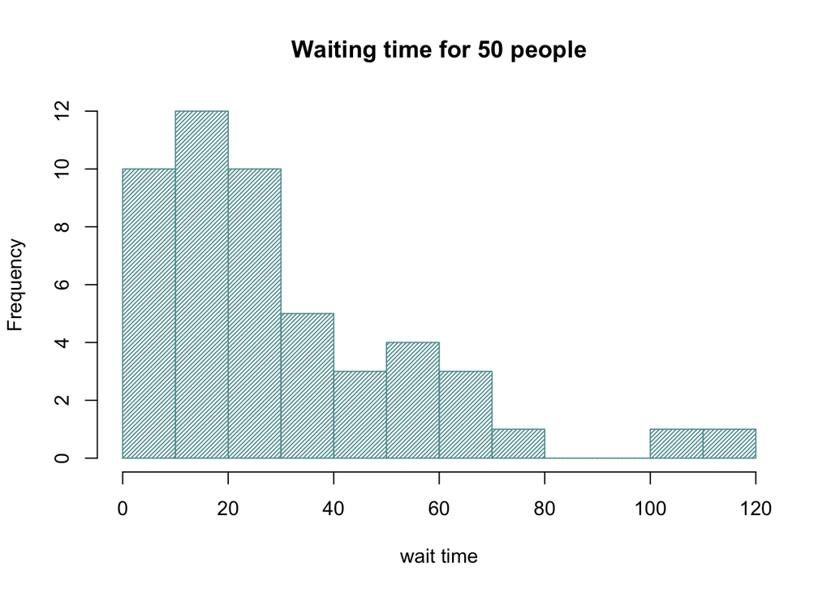

```r
# a)
set.seed(5)
m <- 30
r <- 1/30
people <- 50
x <- seq(0,120,10)
wait_t <- rexp(people,rate=r)
hist(wait_t,
     breaks = 12,
     xlab="wait time",
     main = "Waiting time for 50 people",
     col = "cadetblue",
     density = 40)
```

```r
# b)
p_less10 <- pexp(x[2], r)
cat(paste("The probability that a person waits for less than 10 minutes is", p_less10, "\n"))
```

```
## The probability that a person waits for less than 10 minutes is 0.283468689426211
```

```r
# c)
m <- mean(wait_t)
cat(paste("The mean is", m, "\n"))
```

```
## The mean is 29.8971144575949
```

```r
cat(paste("The expected value of the exponential distribution is", 1/r, "\n"))
```

```
## The expected value of the exponential distribution is 30
```

```r
# d)
p_more60 <- 1-pexp(x[7], r)
cat(paste("The probability that a person waits for more than 1 hour is", p_more60))
```

```
## The probability that a person waits for more than 1 hour is 0.135335283236613
```

## Exercise 3

let’s suppose that on a book, on average, there is one typo error every three pages. If the number of errors follows a Poisson distribution, plot the pdf and cdf, and calculate the probability that there is at least one error on a specific page of the book.

```r
typo <- 1/3
prob_atleastonetypo <- 1 - ppois(0,lambda = typo)
cat(paste("The probability that there is at least one typo on a specific page is", prob_atleastonetypo))
```

```
## The probability that there is at least one typo on a specific page is 0.283468689426211
```

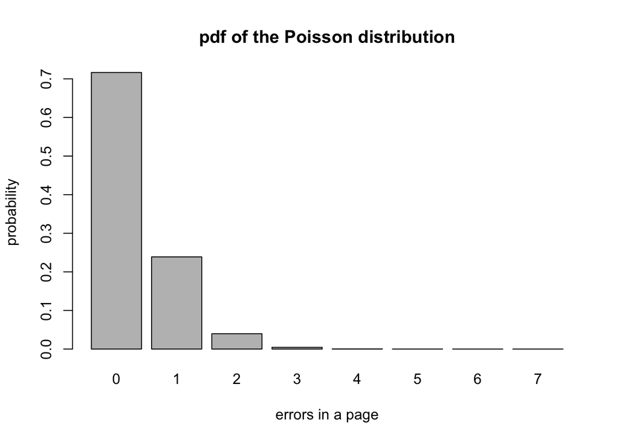

```r
xp <- seq(0,7,1)
d_pois <- dpois(xp,lambda = typo)
p_pois <- ppois(xp,lambda = typo)
barplot(d_pois,
        main = "pdf of the Poisson distribution",
        xlab = "errors in a page",
        ylab = "probability",
        names = xp)
```

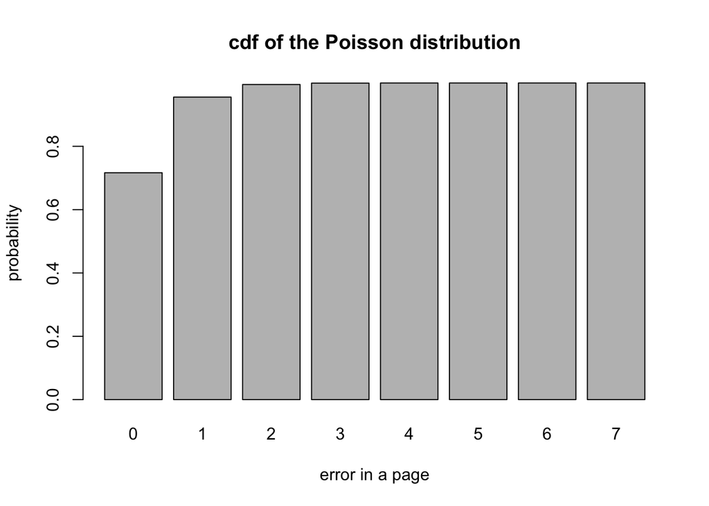

```r
barplot(p_pois,
        main = "cdf of the Poisson distribution",
        xlab = "error in a page",
        ylab = "probability",
        names = xp)
```

## Exercise 4

We randomly draw cards from a deck of 52 cards, with replacement, until one ace is drawn. Calculate the probability that at least 10 draws are needed.

```r
p_ace <- 4/52
pr <- (1-p_ace)^9
pr1 <- 1-dgeom(8, p_ace)-dgeom(7, p_ace)-dgeom(6, p_ace)-dgeom(5, p_ace)-dgeom(4, p_ace)-dgeom(3, p_ace)-dgeom(2, p_ace)-dgeom(1, p_ace)-dgeom(0, p_ace)
paste("The probability that at least 10 draws are needed to find an ace is", pr1)
```

```
## [1] "The probability that at least 10 draws are needed to find an ace is 0.486565199403685"
```

```r
paste("The probability that at least 10 draws are needed to find an ace is", pr)
```

```
## [1] "The probability that at least 10 draws are needed to find an ace is 0.486565199403685"
```

## Exercise 5

The file available at the URL https://userswww.pd.infn.it/~agarfa/didattica/sindaciincarica.csv) contains the list of all mayors currently in charge in the Italian mayors working in local towns in Italy. (Updated to April 6, 2020).

- open R and import the file in a tibble or data.frame.
- plot the gender distribution among the mayors (column name `sesso`)
- plot the number of towns grouped per province (`codice_provincia`) and per region (`codice_regione`)
- plot a distributions of the age (years only) of the mayors. In the `data_nascita` column the birthday is available
- plot a distribution of the time the mayor is in charge. The starting date is in column `data_elezione`. Since elections happen every 5 years, how many of them are going to complete their mandate this year? And how many in 2021?

```r
library(lubridate)
#
sindaci <- read.csv2("sindaciincarica.csv", skip=2)
head(sindaci)
```

```
##   codice_regione codice_provincia codice_comune denominazione_comune
## 1              1                2            10          ACQUI TERME
## 2              1                2            20        ALBERA LIGURE
## 3              1                2            30          ALESSANDRIA
## 4              1                2            40        ALFIANO NATTA
## 5              1                2            50      ALICE BEL COLLE
## 6              1                2            62    ALLUVIONI PIOVERA
##   sigla_provincia popolazione_censita titolo_accademico                cognome
## 1              AL               20054                                 LUCCHINI
## 2              AL                 329                                  LOVOTTI
## 3              AL               89411              PROF CUTTICA DI REVIGLIASCO
## 4              AL                 754                                   ZEGLIO
## 5              AL                 774              ARCH                MARTINO
## 6              AL                1791                                    BETTI
##                 nome sesso data_nascita          luogo_nascita
```

[output cut: 34 more lines]

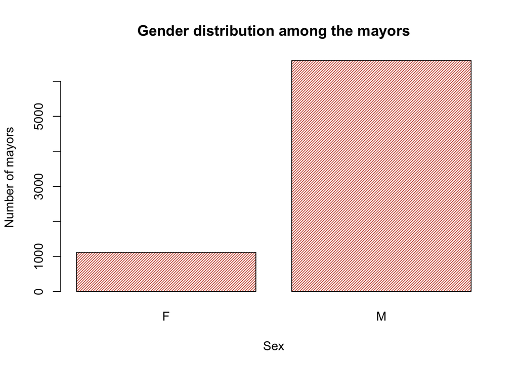

```r
#
sex <- table(sindaci$sesso)
barplot(sex,
        xlab = "Sex",
        ylab = "Number of mayors",
        main = "Gender distribution among the mayors",
        col = "coral3",
        density = 40)
```

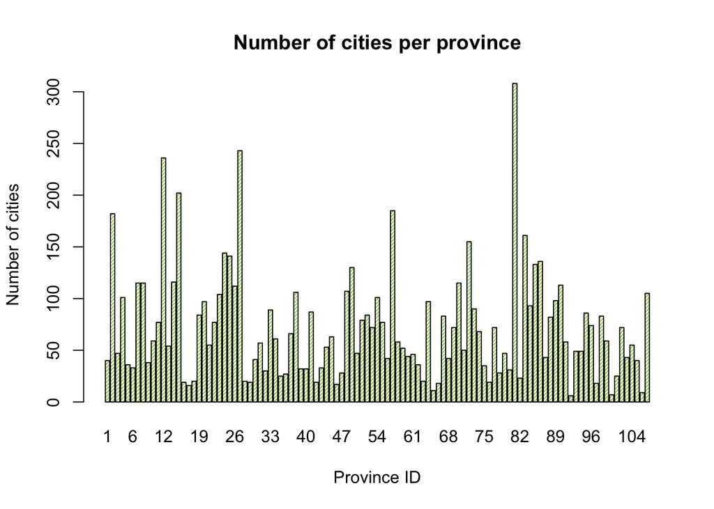

```r
#
town_prov <- table(sindaci$codice_provincia)
barplot(town_prov,
        xlab = "Province ID",
        ylab = "Number of cities",
        main = "Number of cities per province",
        col = "darkolivegreen3",
        density = 40)
```

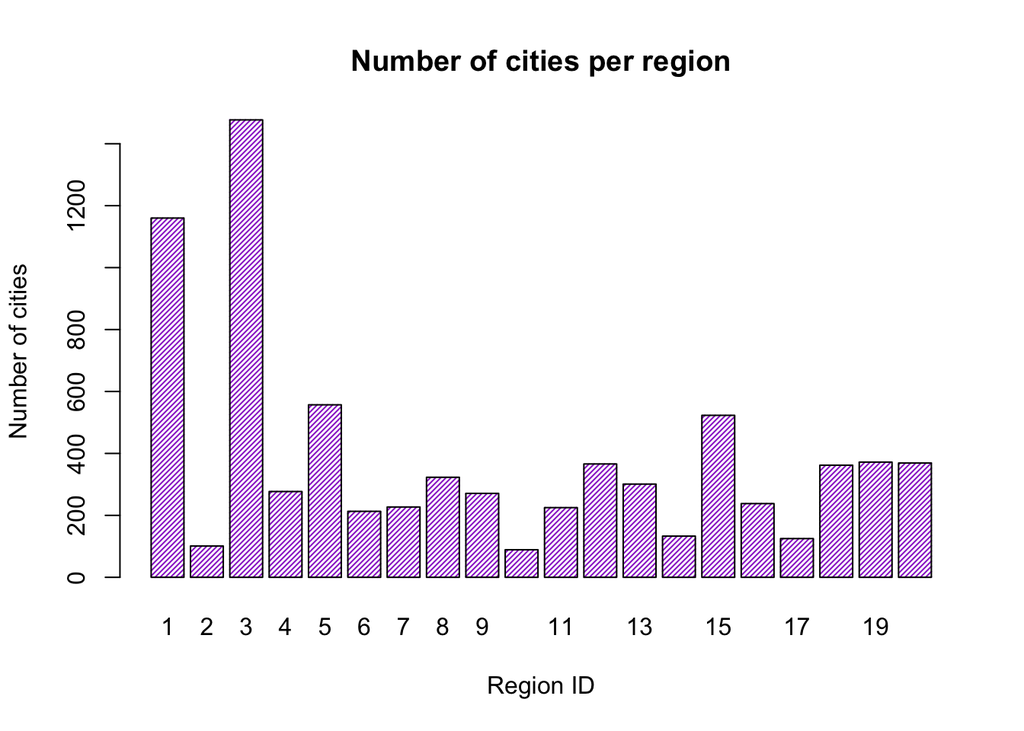

```r
town_reg <- table(sindaci$codice_regione)
barplot(town_reg,
        xlab = "Region ID",
        ylab = "Number of cities",
        main = "Number of cities per region",
        col = "darkorchid3",
        density = 40)
```

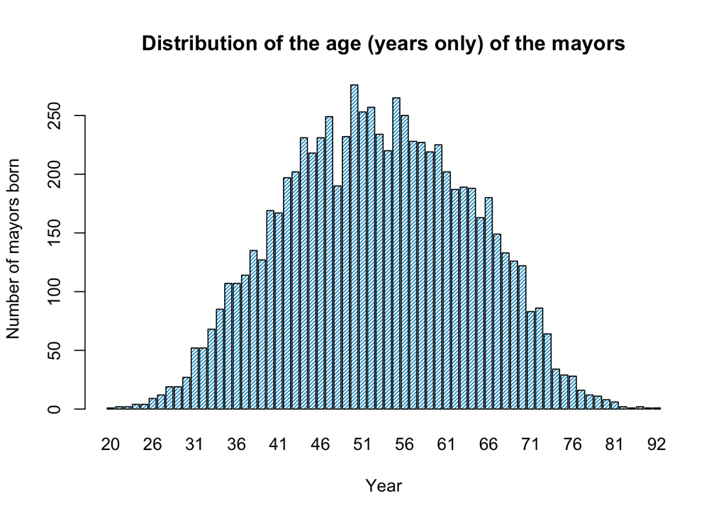

```r
#
datenascita <- format(as.Date(sindaci$data_nascita, format = "%d/%m/%Y"),"%Y-%m-%d")
ages <- as.integer(time_length(difftime(as.Date(today()),as.Date(datenascita)), "years"))
birth <- table(ages)
barplot(birth,
        xlab = "Year",
        ylab = "Number of mayors born",
        main = "Distribution of the age (years only) of the mayors",
        col = "deepskyblue3",
        density = 40)
```

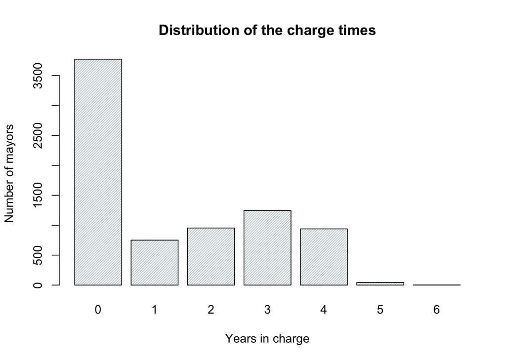

```r
#
# invece di usare data_elezione penso sia più preciso usare data_entrata_in_carica
charge_date <- format(as.Date(sindaci$data_entrata_in_carica, "%d/%m/%Y"), "%Y-%m-%d")
charge_time <- as.integer(time_length(difftime(as.Date(today()),as.Date(charge_date)), "years"))
years_in_charge <- table(charge_time)
chargeplt <- barplot(years_in_charge,
                     xlab = "Years in charge",
                     ylab = "Number of mayors",
                     main = "Distribution of the charge times",
                     col = "azure3",
                     density = 40)
```

```r
complete2020 <- years_in_charge[["4"]]
complete2021 <- years_in_charge[["3"]]
cat(paste("The number of mayors that are going to complete their mandate this year is", complete2020, "\n"))
```

```
## The number of mayors that are going to complete their mandate this year is 939
```

```r
cat(paste("The number of mayors that are going to complete their mandate in 2021 is", complete2021))
```

```
## The number of mayors that are going to complete their mandate in 2021 is 1245
```